# Titanic_Analysis

## 10.1 **comments** :

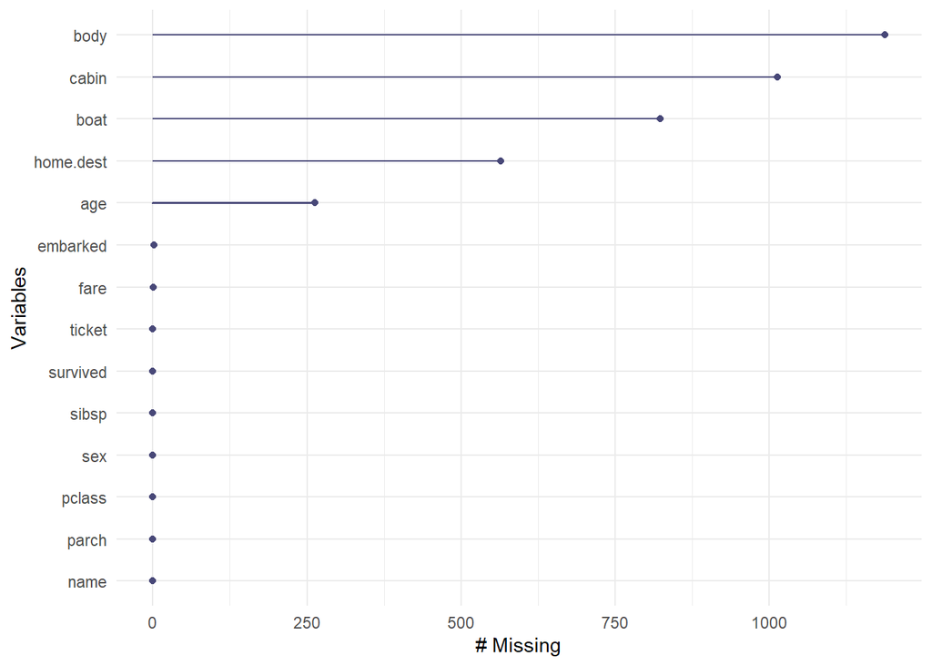

```r
library(rpart)
library(naniar)
gg_miss_var(titanic3)
```

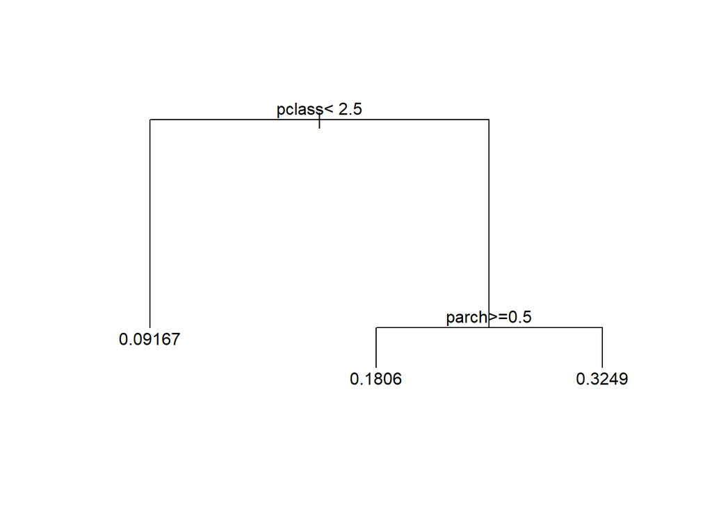

```r
who.na <- rpart(is.na(age) ~ sex + pclass + survived +
                sibsp + parch, data=titanic3, minbucket=30)
plot(who.na, margin=.1); text(who.na)
```

## **comments** : * the problem with single imputation is the distribution of imputed values is different from observed because of the automatic spline transformation of age while multiple imputation doesnot transform age when predicted by another variables but when it is used to predict other variables spline transformation is performed * force class ,parch,sibs to be linear becaus high discrete variables make it difficult to choose knots * Can what aregImpute() does ‘under the hood’ be described as MICE, or is it a different approach? FH: different: bootstrap vs. draws from an approximate multivariate normal distribution for the regression coefficients * imputations number 263/1309=0.2

```r
titanic3[is.na(titanic3) | titanic3=="Inf"] <- NA
set.seed(17)         # so can reproduce random aspects
mi <- aregImpute(~ age + sex + I(pclass) +
                 I(sibsp) + I(parch) + survived,
                 data=titanic3, n.impute=20, nk=4, pr=FALSE)
mi
```

```
##
## Multiple Imputation using Bootstrap and PMM
##
## aregImpute(formula = ~age + sex + I(pclass) + I(sibsp) + I(parch) +
##     survived, data = titanic3, n.impute = 20, nk = 4, pr = FALSE)
##
## n: 1309  p: 6    Imputations: 20     nk: 4
##
## Number of NAs:
##      age      sex   pclass    sibsp    parch survived
##      263        0        0        0        0        0
##
##          type d.f.
## age         s    1
## sex         c    1
## pclass      l    1
## sibsp       l    1
## parch       l    1
## survived    l    1
##
## Transformation of Target Variables Forced to be Linear
##
## R-squares for Predicting Non-Missing Values for Each Variable
## Using Last Imputations of Predictors
##  age
## 0.28
```

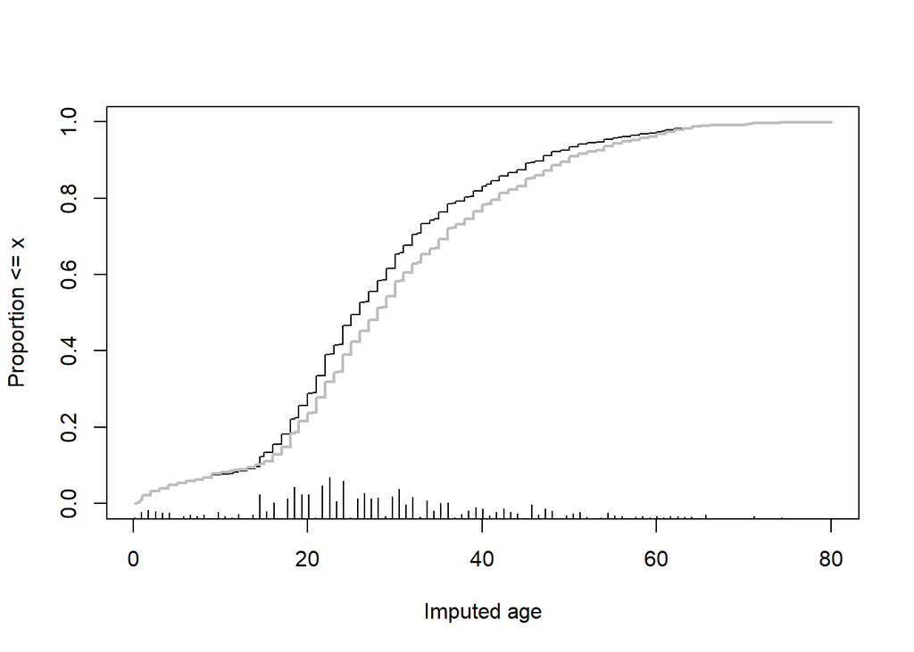

```r
plot(mi)
Ecdf(titanic3$age, add=TRUE, col='gray', lwd=2,subtitles=FALSE)
```